# OLS, interactions and generalized linear models

GEOG 531 · Instructor guide and independent numerical reference

The student Quarto file is self-contained. The values below come from an independent Python implementation of the same reproducible generator. They are not evidence that native R, Quarto or sphet were executed here.

## Why this dataset works

There are 736 synthetic tracts nested in 46 synthetic county groups in hypothetical 2025. The continuous health outcome allows OLS. The numeric heat-day count demonstrates that predictor type does not determine the regression family. Multiple tracts within each county make county fixed effects identifiable. The schematic lattice supplies an explicit neighborhood graph, including neighbors across county borders, without a GIS download.

The data were constructed with a known total heat effect of **0.18** mean poor-health days per additional heat day. The direct component is 0.10 and the disruption pathway adds 0.08. Five additional heat days therefore have a true total contrast of 0.90. The mean also includes poverty, a curved impervious-cover relationship, and a county-constant context. The residual process has spatial autoregression rho = 0.70 with heteroskedastic innovations.

Keep the DAG and the simulation truth separate in the discussion. The DAG defines which pathways to address. The known truth permits a method check that is unavailable with ordinary observational data.

## Setup and timing

Upload only the main .qmd to Posit Cloud, install its core packages once, and run the chunks in order. Do this in a base instructor project before copying it to students. Leave run_spatial false for the core lab. The optional spatial packages can bring compiled dependencies, so install them before the class that will use them.

Allow about two meetings for the guided diagnostics, with the actual spatial-error model as a continuation. Students should interpret completed code, rather than derive the simulation or covariance calculations. Use five pairs if the class still has ten students. Have them swap driver and interpreter after the initial adjusted model.

## Expected model progression

| Model | Observed heat slope | Expected slope, fixed design | Conditional bias | Residual Moran I |
| --- | --- | --- | --- | --- |
| Crude | 0.2937 | 0.3065 | +0.1265 | 0.366 |
| Measured adjustment | 0.2596 | 0.2752 | +0.0952 | 0.391 |
| Add curvature | 0.2427 | 0.2580 | +0.0780 | 0.483 |
| Add county FE | 0.1620 | 0.1800 | +0.0000 | 0.232 |

The crude slope is about 0.294 and measured adjustment gives about 0.260. Improving the impervious mean form gives about 0.243. Adding county effects yields about 0.162 in this sample. That last estimate is not exactly the true 0.180 because one realization still contains random outcome variation. Under the fixed design, the adequate mean model's expected slope is exactly 0.180.

The I statistic can increase after adding a predictor or improving the mean model, because unexplained geographic pattern becomes more visible relative to remaining variation. Spatial diagnostics are not required to improve monotonically at every step. rho and Moran's I are different quantities, so a residual I of about 0.232 is compatible with a data-generating rho of 0.70.

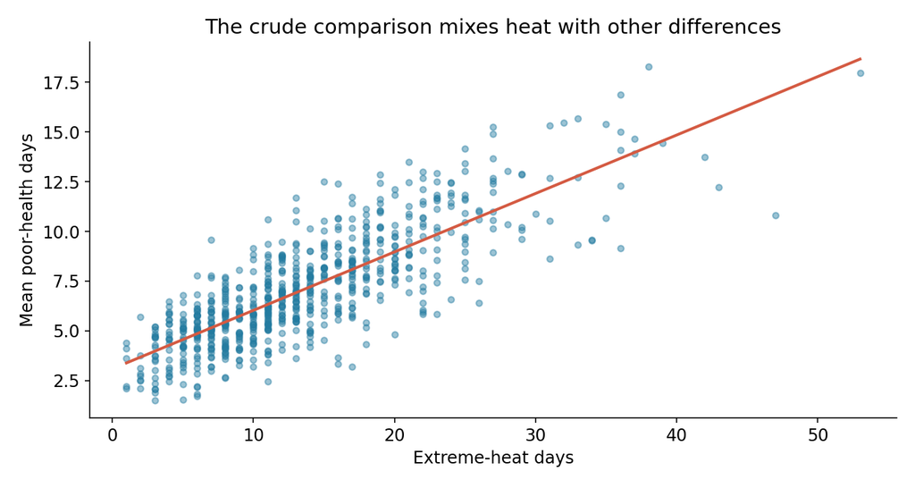

Numerical preview of the crude relation, based on the clean simulated data.

## Checkpoint answers

1. **Audit:** one raw value exceeds 30. The row is T0371. Correct it from the supplied verified source, rather than deleting it based on model output. The clean data have no missing values, no duplicate IDs and health values between roughly 1.50 and 18.29. Heat days range from 1 to 53.
2. **DAG:** poverty, impervious cover and county context create specified backdoor paths. Disruption is a mediator of the total heat effect. The hardship index is a noisy near-duplicate measure of poverty and creates no additional causal pathway in this simulation once poverty is known. County ID is the identifier used to absorb context, not a biological cause.
3. **Crude:** one additional heat day is associated with about 0.294 more mean poor-health days. Five additional heat days correspond to about 1.469 on the crude fitted line. It combines the heat relationship with other differences and should not be called an identified causal effect.
4. **Adjusted:** at the same measured poverty and impervious cover, one additional heat day is associated with about 0.260 more mean poor-health days in the initial linear mean model. County context remains omitted and the impervious form is imperfect. Adjustment alone does not resolve everything.
5. **Bias:** a one-sample estimate-minus-truth discrepancy is estimation error. The oracle conditional-mean fit removes random errors and gives the expected fitted slope conditional on the fixed design. This yields actual conditional procedure bias, not just one noisy estimate. In real data that oracle is unavailable, and residual orthogonality cannot verify exchangeability.
6. **Collinearity:** retain the measured confounder poverty and omit its redundant proxy under this DAG. This is not permission to remove arbitrary controls based on p-values or a VIF threshold. Rescaling the duplicate variables would not remove their redundancy.
7. **Mean form:** residuals versus impervious cover show curvature. A squared centered impervious term addresses this specified relationship while retaining the linear term. It changes functional form rather than discovering a new causal variable. County confounding and dependence still remain.
8. **Influence:** investigate source quality, unusual exposure combinations and residual size. The largest Cook's distances are not an automatic deletion list. An influential valid observation and a verified data-entry error require different responses.
9. **County FE:** the estimate compares remaining within-county heat variation after other included terms. It absorbs additive county-constant context, but cannot eliminate tract-varying omitted confounding in real data or model spatial covariance by itself.
10. **Spatial pattern:** residual clustering remains across neighboring tracts and can cross county boundaries. HC3 is not spatially robust. A spatial-error process is appropriate here because that is how the synthetic errors were generated; I alone does not identify the correct spatial mechanism.
11. **Spatial continuation:** sphet::spreg with model="error" and het=TRUE allows the heteroskedastic innovations deliberately retained in this dataset. Its estimates were not generated here. Compare actual R output with the county-FE OLS estimate, without promising an exact coefficient, smaller SE, or automatic causal validity.

## VIF reference

| Specification | Term | VIF |
| --- | --- | --- |
| With proxy | Heat | 1.9 |
| With proxy | Poverty | 1423.2 |
| With proxy | Impervious | 1.6 |
| With proxy | Hardship proxy | 1423.5 |
| Without proxy | Heat | 1.87 |
| Without proxy | Poverty | 1.26 |
| Without proxy | Impervious | 1.55 |

The hardship proxy is deliberately extreme to make the problem easy to see. High VIF inflates uncertainty in separating overlapping coefficient contributions. It is not the same phenomenon as omitted-confounder bias. The heat coefficient barely changes when the duplicate is added or removed in this realization.

## Functional form and uncertainty

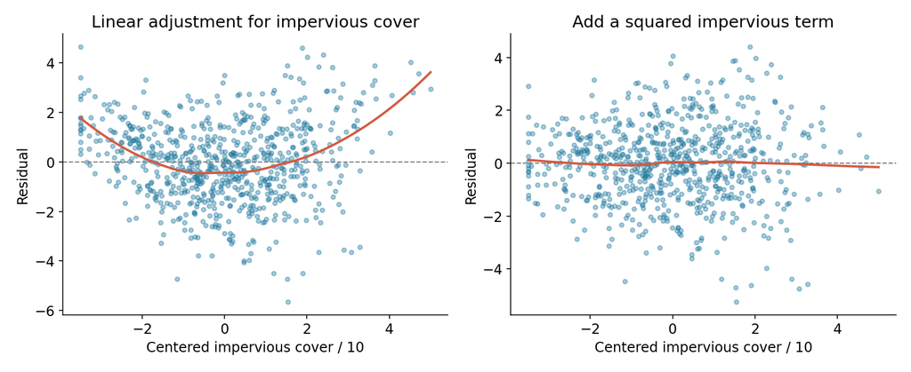

Independent local-quadratic smooth previews; native ggplot2 loess interpolation can differ slightly.

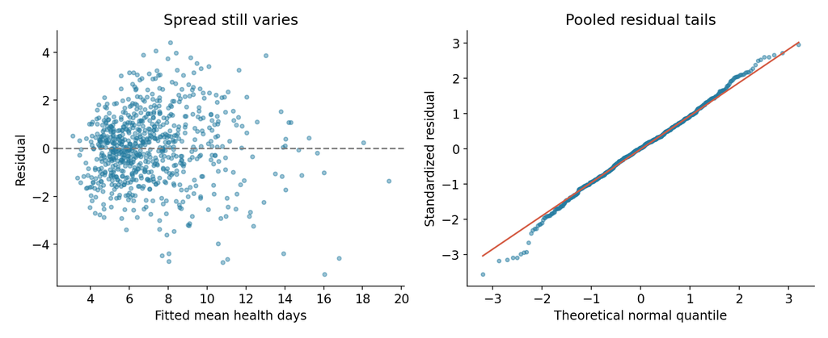

Variance and residual-tail previews for the curved mean model before county effects.

For the curved model, the heat SE is about 0.00999 ordinarily and 0.01220 with HC3. For the county-FE model it is about 0.01134 ordinarily and 0.01549 with HC3. These differences illustrate covariance assumptions, but neither ordinary nor HC3 uncertainty fully handles the remaining spatial dependence. The Breusch–Pagan screen should not be taught as a decisive test with a valid usual p-value under this simulation's known dependence.

Normality of the raw exposure or outcome is not an OLS requirement. A pooled Q–Q plot can depart from normality because different observations have different conditional variances. Do not hunt transformations to make every histogram look normal.

## Spatial bridge

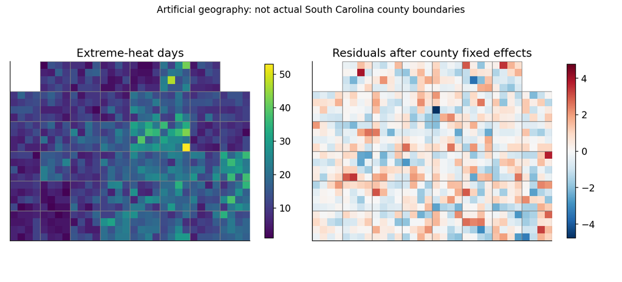

Schematic exposure and county-FE residual maps; these are not actual South Carolina geographies.

The main lab uses descriptive Moran's I without a p-value, avoiding an unjustified residual-exchangeability or homoskedastic reference in a deliberately heteroskedastic dataset. The graph is known by construction. Do not casually substitute a raw-variable Moran test for an OLS residual test. Formal inference should match the mean, variance and dependence assumptions.

The spatial-error continuation is off by default and contains real runnable R calls, not fabricated output. Do not interpret a spatial-lag slope identically without calculating impacts if switching to an outcome-spillover model later. Raw spatial-error disturbances may remain correlated by design; model checks should target appropriate filtered innovations.

## Optional direct-effect comparison

The mediator-adjusted sample heat coefficient is about 0.134, compared with about 0.162 for the total-effect model. The known direct truth is 0.10. This is an opportunity to distinguish changed estimands, collinearity/precision and finite-sample variation. In real data mediator adjustment can introduce other bias unless additional assumptions hold.

## Numerical validation benchmark

A Python oracle GLS calculation using the known simulated spatial filter and innovation variances gives a heat coefficient of about 0.1803 with SE about 0.00897. This is only a simulation QA benchmark. It is not a claimed sphet fit, not a guaranteed value students will obtain, and not an estimator available in ordinary real data where that covariance is unknown.

## Boundaries of verification

Independent Python checks cover the generator, correct row order, data audit, conditional mean and bias, known effect, OLS/HC3 calculations, VIFs, variance patterns and residual I. Native R/Quarto rendering and the optional sphet optimization were unavailable during creation. The instructor should render once in Posit Cloud and save a prepared project before distributing it. The data and figures are simulated teaching materials, not substantive South Carolina evidence.

## New: categorical predictors and three interaction types

The original continuous-outcome workflow and its constant total heat truth of 0.18 per day remain intact. The added module creates `poor_health_days_modified`, a related outcome variant with known categorical differences and effect modification. The original constant-effect oracle must not be used to assess this variant.

Categories are pre-exposure tract attributes: cooling access has Limited/Partial/Reliable levels; housing profile has Standard/Vulnerable levels; warning program has No/Yes levels. The references are Limited, Standard and No. `heat5` is centered at 15 heat days in five-day units; `poverty10` is centered at 20% poverty in ten-percentage-point units. The warning program is independently assigned in this teaching process, while housing probability depends partly on poverty.

The three examples use one correctly specified joint interaction model, so their interpretations do not silently omit other known effect modification. The categorical × categorical example asks about program differences by housing group; it does not dichotomize the continuous heat predictor. The sample still has spatial errors, so ordinary OLS intervals are working intervals and should not be presented as final valid spatial inference. An optional spatial-error refit of the full interaction formula is included.

| Focal coefficient | Simulation truth | Sample estimate |
| --- | --- | --- |
| heat5 | +0.900 | +0.795 |
| heat5:poverty10 | +0.250 | +0.183 |
| heat5:cooling_accessPartial | -0.200 | -0.122 |
| heat5:cooling_accessReliable | -0.450 | -0.373 |
| warning_programYes:housing_profileVulnerable | -0.650 | -0.301 |

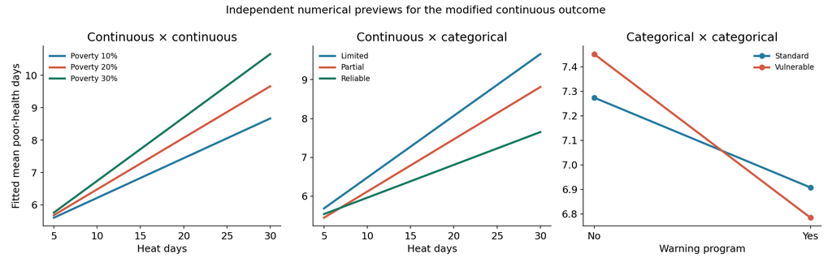

Point-prediction previews: common reference profiles, without uncertainty bands.

### Continuous × continuous checkpoint

Poverty is both a confounder and an effect modifier in this variant. These are different roles and need not be mutually exclusive.

At Limited cooling and the same other profile values, the five-day heat contrast varies with poverty. The interaction is the change in this contrast for a ten-percentage-point poverty increase.

| Poverty | Estimated five-day contrast | Known contrast |
| --- | --- | --- |
| 10% | 0.612 | 0.65 |
| 20% | 0.795 | 0.90 |
| 30% | 0.978 | 1.15 |

### Continuous × categorical checkpoint

At 20% poverty, the heat main coefficient applies to Limited cooling. Add the relevant heat-by-cooling term for the other groups. A main cooling coefficient describes a group difference at 15 heat days, not a constant difference over every heat exposure.

| Cooling | Estimated five-day heat contrast | Known contrast |
| --- | --- | --- |
| Limited | 0.795 | .90 |
| Partial | 0.673 | .70 |
| Reliable | 0.423 | .45 |

### Categorical × categorical checkpoint

The program main coefficient is the Yes-minus-No difference for Standard housing. Add the program-by-housing term for Vulnerable housing. Subtract the two program differences to obtain the interaction. This is difference-in-differences arithmetic on a cross-sectional contrast, not a longitudinal identification design.

| Housing | Estimated program difference | Known difference |
| --- | --- | --- |
| Standard | -0.367 | −0.25 |
| Vulnerable | -0.667 | −0.90 |

The observed program interaction is about -0.301, while its known value is −0.65. Finite-sample noise and imprecision remain even when the specified effect modification is real. Do not teach that a p-value must be small in every simulated realization. The independent noise-free reference recovers all the specified interaction coefficients exactly.

Adding a three-level factor introduces two reference contrasts; numeric 1/2/3 coding would impose equal spacing. Centering changes the interpretation of main terms and the intercept, but does not remove the need for interaction hierarchy. A contrast SE generally uses the full covariance matrix. Comparing “significant in one group” with “not significant in another” is not an interaction test.

## New companion lab: logistic and Poisson

`GEOG531_SC_Heat_Logistic_Poisson.qmd` is self-contained and recreates its data without reading the first lab. The binary outcome is one sampled resident's illness status over the complete hypothetical year. Counts are annual tract emergency episodes over varying positive person-years, allowing repeated episodes.

For teaching clarity, these GLM outcomes have independent errors conditional on their measured predictors. They do not inherit the original continuous outcome's spatial error. County context affects covariates/exposure but has no remaining direct GLM outcome contribution after the specified predictors. Poverty and impervious cover block the designated heat backdoors. The original disruption mediator is absent from these simplified outcome-generating equations. This outcome-specific distinction is explicit in the student DAG and should be discussed.

Both GLMs include heat × cooling interactions on their respective link scales. Exponentiated slope interactions are ratios of ORs or IRRs. The heat main ratio applies to Limited cooling, and main cooling ratios apply at 15 heat days. Probability differences can vary across profiles even without an explicit log-odds interaction.

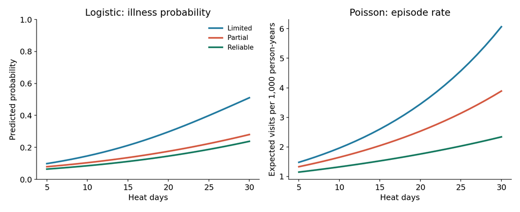

Independent logistic and Poisson point-prediction previews at the stated reference profile.

| Cooling | Estimated heat OR per five days | Estimated heat IRR per five days |
| --- | --- | --- |
| Limited | 1.570 | 1.326 |
| Partial | 1.353 | 1.239 |
| Reliable | 1.354 | 1.153 |

### Logistic reference and diagnostic responses

There are 152 events among 736 binary observations. In-sample Brier score is about 0.1333. Calibration-bin differences are finite-sample variation; in-sample agreement is not transportability or causal validation. Inspect coding, sparse cells, convergence, coefficient magnitude, functional form and influence. Residual normality and a blanket .5 accuracy threshold are unsuitable validation targets.

| Cooling | P(illness), heat=10 | P(illness), heat=15 | Difference, percentage points |
| --- | --- | --- | --- |
| Limited | 14.64% | 21.22% | +6.58 |
| Partial | 10.41% | 13.59% | +3.18 |
| Reliable | 8.50% | 11.18% | +2.67 |

These are fixed-profile point predictions, not observed group averages, average marginal effects or intervals for differences. ORs and probability differences are different scales. A changed OR after adding an outcome predictor alone does not prove confounding.

### Poisson and negative-binomial reference

| Cooling | Visits per 1,000 PY, heat=10 | Visits per 1,000 PY, heat=20 |
| --- | --- | --- |
| Limited | 1.962 | 3.450 |
| Partial | 1.649 | 2.533 |
| Reliable | 1.325 | 1.761 |

At an identical profile, changing person-years from 1,000 to 2,000 doubles the expected count and leaves the rate unchanged. Expected counts may be fractional. The offset has fixed coefficient one and keeps the integer count as the response.

| Fit/outcome | Pearson ratio |
| --- | --- |
| Poisson / main outcome | 1.055 |
| Poisson / extra-variation outcome | 6.355 |
| NB / extra-variation outcome | 0.972 |

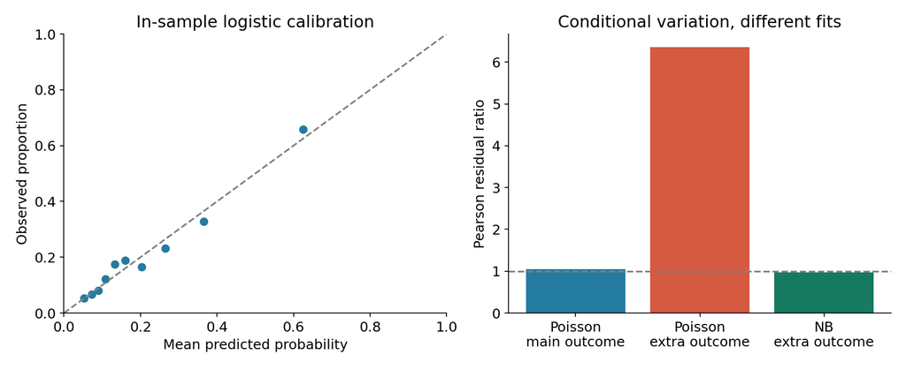

In-sample calibration and conditional count-dispersion reference screens.

The main Poisson outcome has an approximately unit residual ratio. The extra outcome shows substantial overdispersion. Quasi-Poisson keeps the same mean estimates but scales uncertainty; it does not provide an ordinary AIC for the same likelihood comparison. Negative binomial uses another variance distribution and its fitted coefficients can change. The NB theta estimate is about 1.542 against a simulation truth of 1.5.

| Model, same extra-variation response | AIC |
| --- | --- |
| Poisson | 6418.93 |
| Negative binomial | 3906.79 |

Do not compare AIC across the main and extra outcomes. A Poisson marginal variance above its marginal mean is not enough to diagnose conditional overdispersion. Extra zeros can arise under NB heterogeneity without a separate structural-zero process. Neither a near-unit ratio nor negative binomial establishes no confounding or independence.

## Pre-class verification for the additions

The R code has been checked structurally and against an independent Python generator/likelihood implementation. The Bernoulli generator uses the inverse-CDF rule, matching R's qbinom. Poisson and NB count quantiles, row order and factor references match the documented construction. Numerical checks cover full-rank design, all factor cells, exact oracle interaction coefficients, GLM score equations, the offset scaling, and the overdispersion/NB likelihood comparisons. Native R/Quarto and the optional spatial GMM fits were unavailable here, so render both sources once in the prepared Posit Cloud project before distributing them.

The extended OLS module adds about 45–60 minutes. The GLM lab is another two modular meetings, with the overdispersion work as an optional continuation. All question answers should emphasize the target comparison, scale, assumptions and uncertainty rather than treating p-values as a model-building algorithm.